# 06 - Model Fitting and Recommendation Systems Comprehension Check

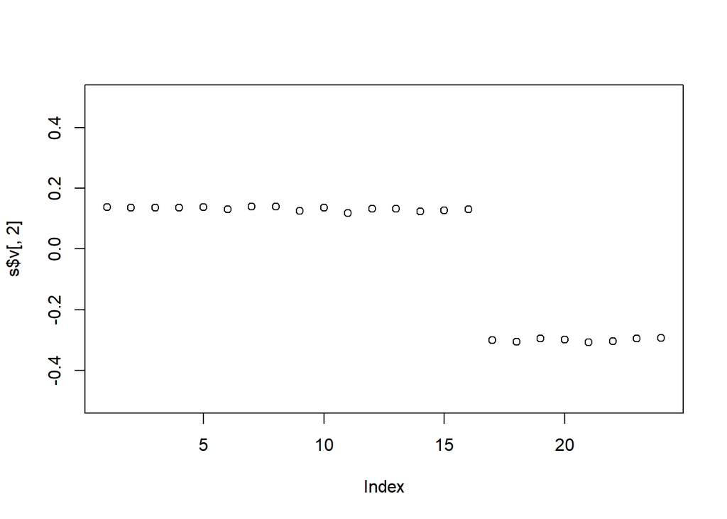

```r
plot(s$v[,2], ylim = c(-0.5, 0.5))
```

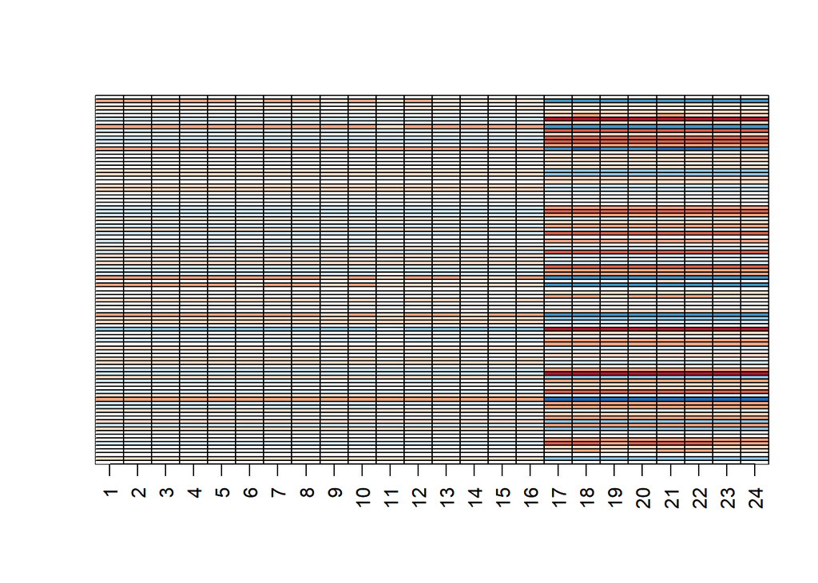

```r
with(s, my_image((u[, 2, drop=FALSE]*d[2]) %*% t(v[, 2, drop=FALSE])))
```

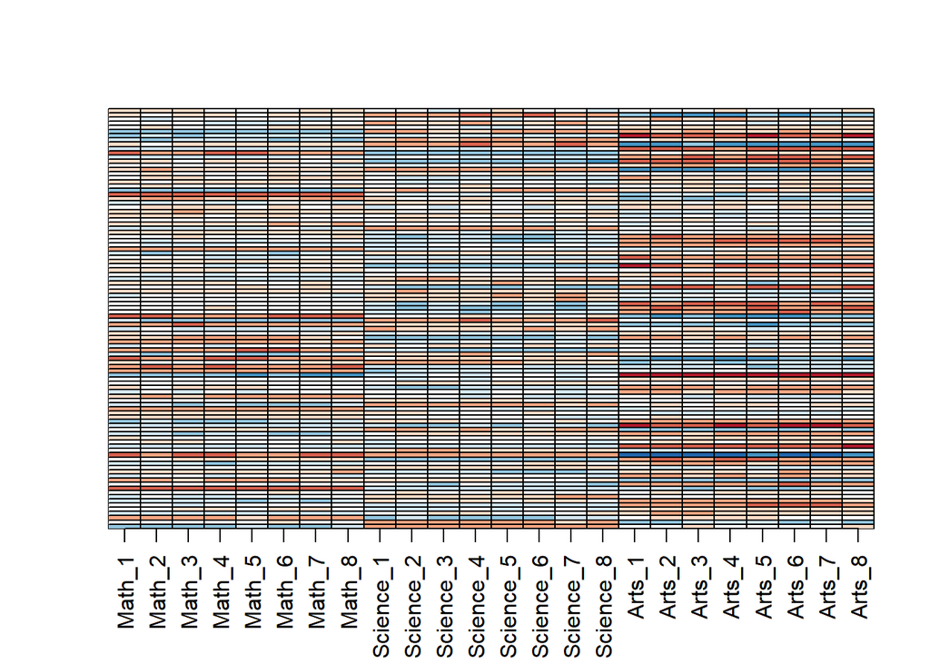

```r
my_image(resid)
```

### **Question 12**

The second column clearly relates to a student’s difference in ability in math/science versus the arts. We can see this most clearly from the plot of `s$v[,2]`. Adding the matrix we obtain with these two columns will help with our approximation:

$\ Y \approx d_{1,1} U_1 V_1^{\top} + d_{2,2} U_2 V_2^{\top}$

We know it will explain `sum(s$d[1:2]^2)/sum(s$d^2) * 100` percent of the total variability. We can compute new residuals like this:

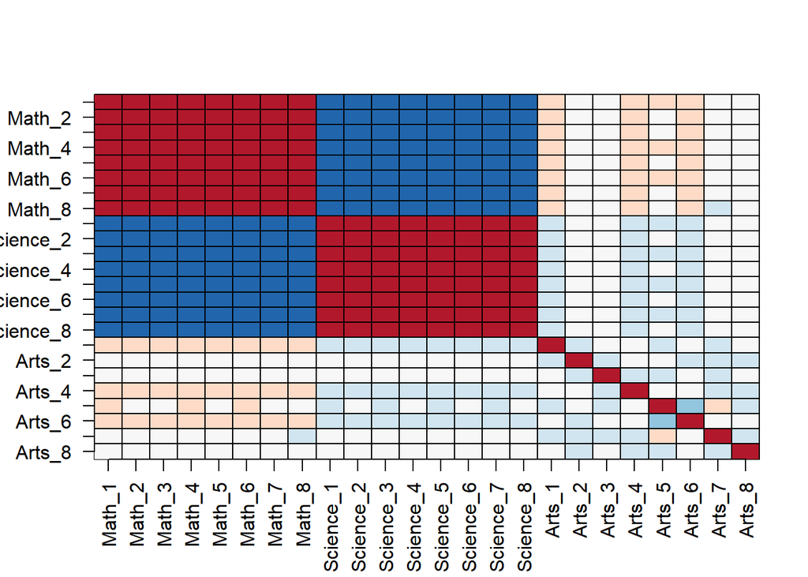

```r
resid <- y - with(s,sweep(u[, 1:2], 2, d[1:2], FUN="*") %*% t(v[, 1:2]))
my_image(cor(resid), zlim = c(-1,1))
axis(side = 2, 1:ncol(y), rev(colnames(y)), las = 2)
```

and see that the structure that is left is driven by the differences between math and science. Confirm this by first plotting $\ U_3$, then plotting $\ V_3^{\top}$ using the same range for the y-axis limits, then making an image of $\ U_3 d_{3,3} V_3 ^{\top}$ and comparing it to the image of `resid`.

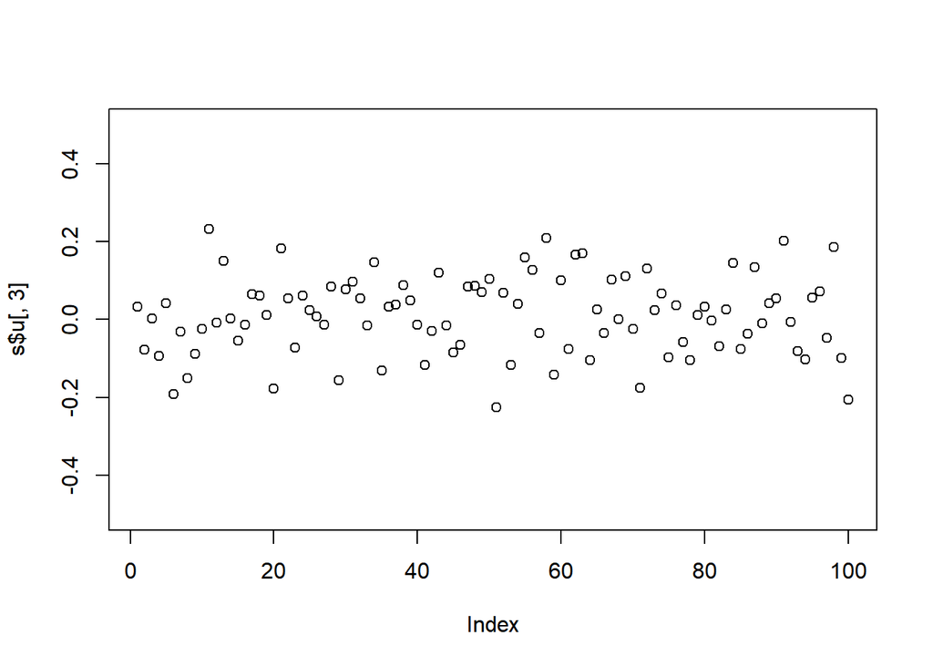

```r
plot(s$u[,3], ylim = c(-0.5, 0.5))
```

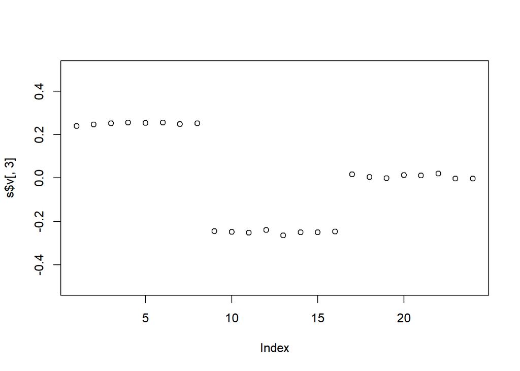

```r
plot(s$v[,3], ylim = c(-0.5, 0.5))
```

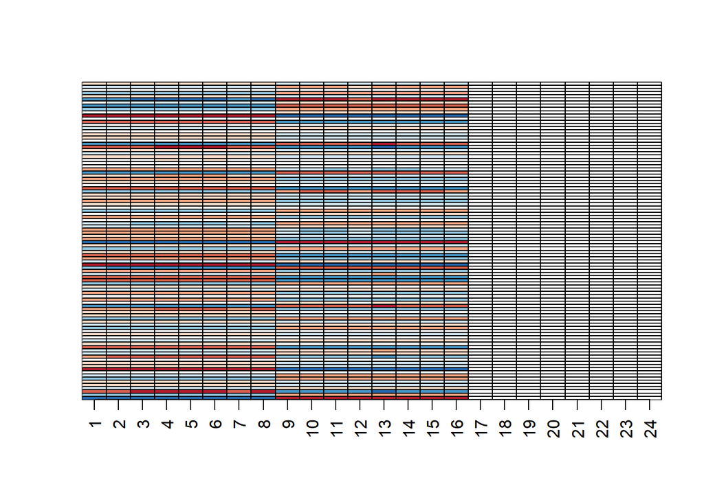

```r
with(s, my_image((u[, 3, drop=FALSE]*d[3]) %*% t(v[, 3, drop=FALSE])))
```

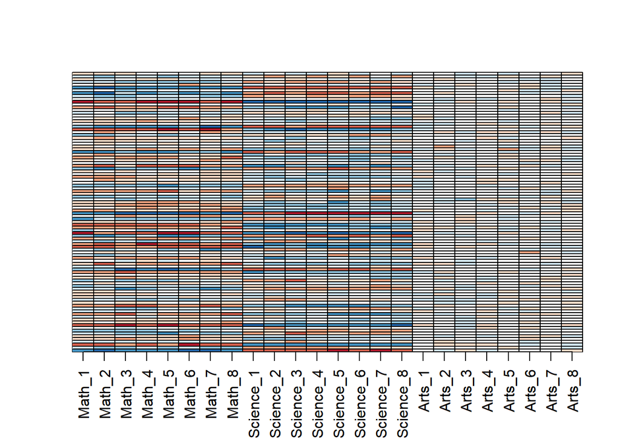

```r
my_image(resid)
```

### **Question 13**

The third column clearly relates to a student’s difference in ability in math and science. We can see this most clearly from the plot of `s$v[,3]`. Adding the matrix we obtain with these two columns will help with our approximation:

$\ Y \approx d_{1,1} U_1 V_1^{\top} + d_{2,2} U_2 V_2^{\top} + d_{3,3} U_3 V_3^{\top}$

We know it will explain: sum(s$d[1:3]^2)/sum(s$d^2) * 100 percent of the total variability. We can compute new residuals like this:

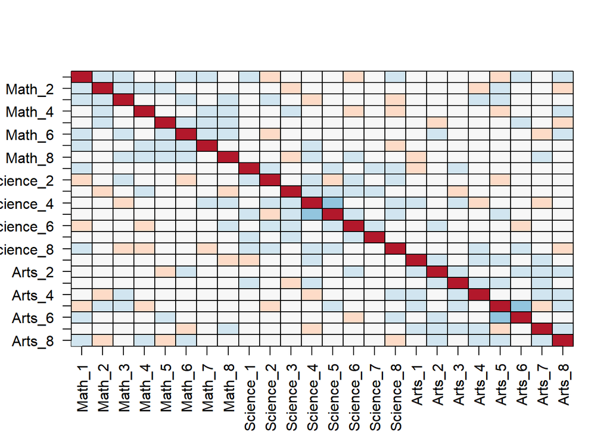

```r
resid <- y - with(s,sweep(u[, 1:3], 2, d[1:3], FUN="*") %*% t(v[, 1:3]))
my_image(cor(resid), zlim = c(-1,1))
axis(side = 2, 1:ncol(y), rev(colnames(y)), las = 2)
```

We no longer see structure in the residuals: they seem to be independent of each other. This implies that we can describe the data with the following model:

$\ Y = d_{1,1} U_1 V_1^{\top} + d_{2,2} U_2 V_2^{\top} + d_{3,3} U_3 V_3^{\top} + \varepsilon$

with $\ \varepsilon$ a matrix of independent identically distributed errors. This model is useful because we summarize of 100 x 24 observations with 3 X (100+24+1) = 375 numbers.

Furthermore, the three components of the model have useful interpretations:

1 - the overall ability of a student 2 - the difference in ability between the math/sciences and arts 3 - the remaining differences between the three subjects.

The sizes $\ d_{1,1}, d_{2,2}$ and $\ d_{3,3$} tell us the variability explained by each component. Finally, note that the components $\ d_{j,j} U_j V_j^{\top}$ are equivalent to the jth principal component.

Finish the exercise by plotting an image of $\ Y$, an image of $\ d_{1,1} U_1 V_1^{\top} + d_{2,2} U_2 V_2^{\top} + d_{3,3} U_3 V_3^{\top}$ and an image of the residuals, all with the same `zlim`.

```r
y_hat <- with(s,sweep(u[, 1:3], 2, d[1:3], FUN="*") %*% t(v[, 1:3]))
my_image(y, zlim = range(y))
```

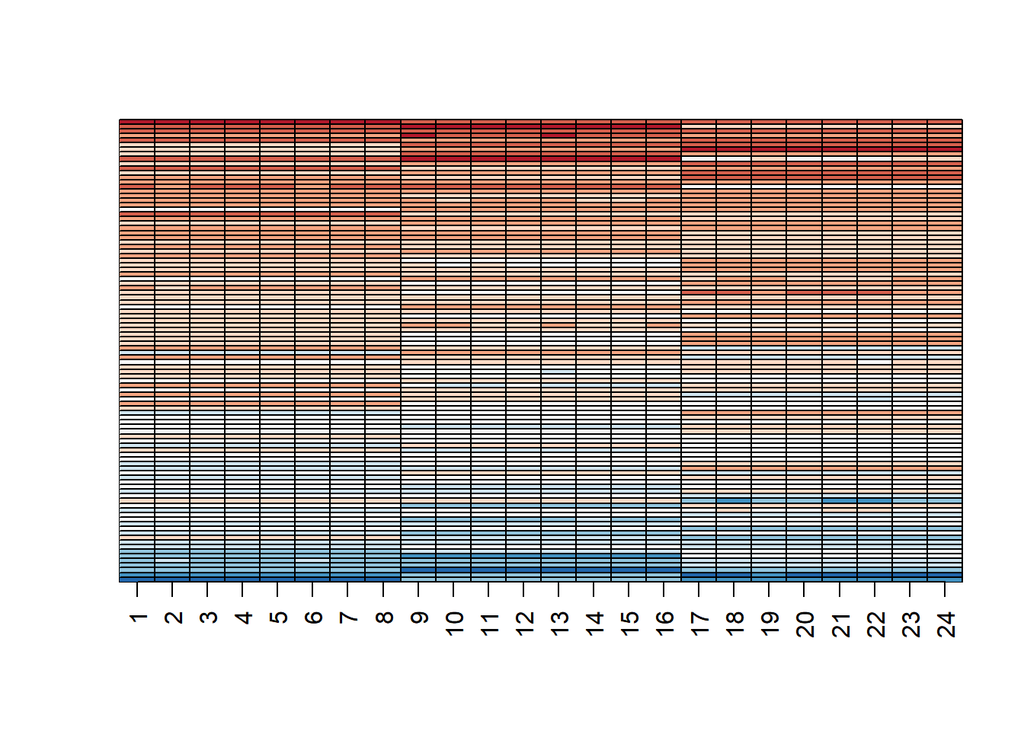

```r
my_image(y_hat, zlim = range(y))
```

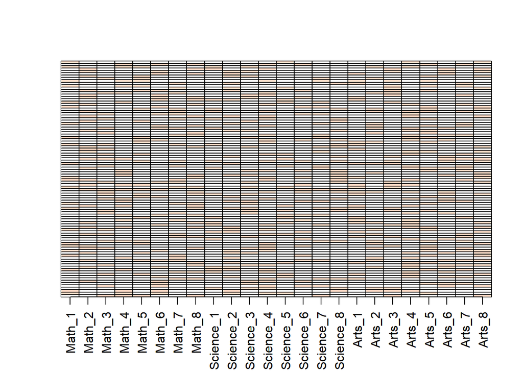

```r
my_image(y - y_hat, zlim = range(y))
```

## **Clustering**

These exercises will work with the tissue_gene_expression dataset, which is part of the dslabs package.

### **Question 1**

Load the `tissue_gene_expression` dataset. Remove the row means and compute the distance between each observation. Store the result in `d`.

Which of the following lines of code correctly does this computation?

```r
d <- dist(tissue_gene_expression$x - rowMeans(tissue_gene_expression$x))
```

- `d <- dist(tissue_gene_expression$x)`
- `d <- dist(rowMeans(tissue_gene_expression$x))`
- `d <- dist(rowMeans(tissue_gene_expression$y))`
- `d <- dist(tissue_gene_expression$x - rowMeans(tissue_gene_expression$x))`[X]

### **Question 2**

Make a hierarchical clustering plot and add the tissue types as labels.

You will observe multiple branches.

Which tissue type is in the branch farthest to the left?

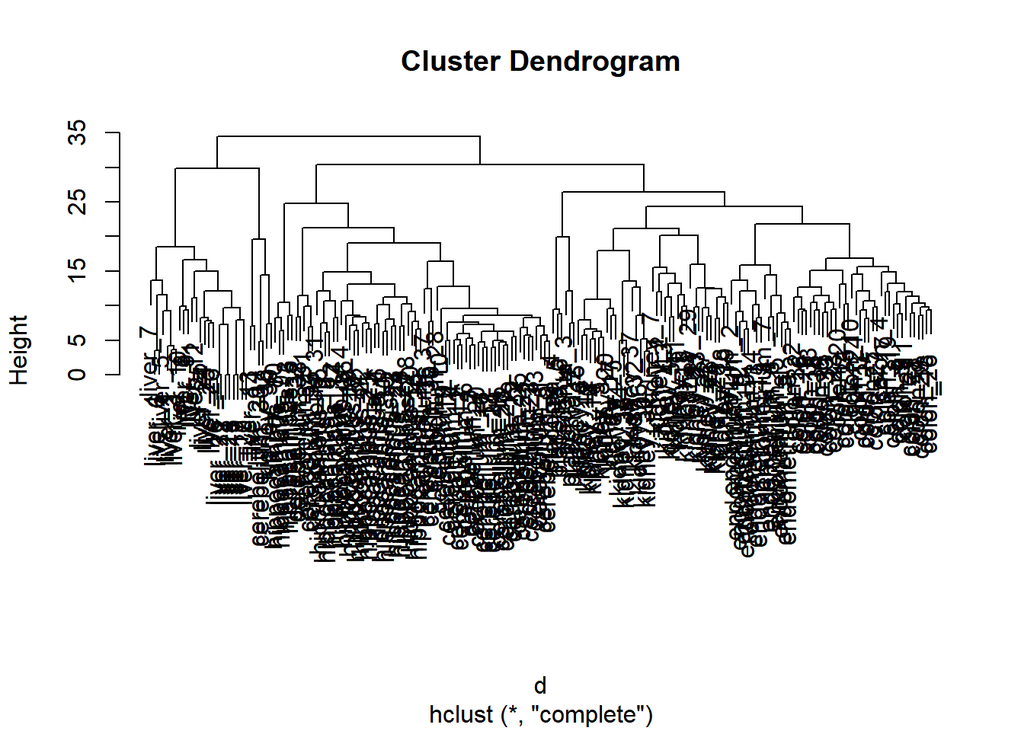

```r
h <- hclust(d)
plot(h)
```

- cerebellum - colon - endometrium - hippocampus - kidney - liver [X] - placenta

### **Question 3**

Run a k-means clustering on the data with $\ K = 7$. Make a table comparing the identified clusters to the actual tissue types. Run the algorithm several times to see how the answer changes.

What do you observe for the clustering of the liver tissue?

```r
cl <- kmeans(tissue_gene_expression$x, centers = 7)
table(cl$cluster, tissue_gene_expression$y)
```

```
##
##     cerebellum colon endometrium hippocampus kidney liver placenta
##   1         36     0           0          31      0     0        0
##   2          0     0           0           0     12     0        0
##   3          0     0           0           0      0     7        0
##   4          2     0           0           0      2     2        0
##   5          0    34           1           0      0     0        6
##   6          0     0           0           0      0    17        0
##   7          0     0          14           0     25     0        0
```

- Liver is always classified in a single cluster.
- Liver is never classified in a single cluster.
- Liver is classified in a single cluster roughly 20% of the time and in more than one cluster roughly 80% of the time. [X]
- Liver is classified in a single cluster roughly 80% of the time and in more than one cluster roughly 20% of the time.

### **Question 4**

Select the 50 most variable genes. Make sure the observations show up in the columns, that the predictor are centered, and add a color bar to show the different tissue types. Hint: use the ColSideColors argument to assign colors. Also, use col = RColorBrewer::brewer.pal(11, “RdBu”) for a better use of colors.

Part of the code is provided for you here:

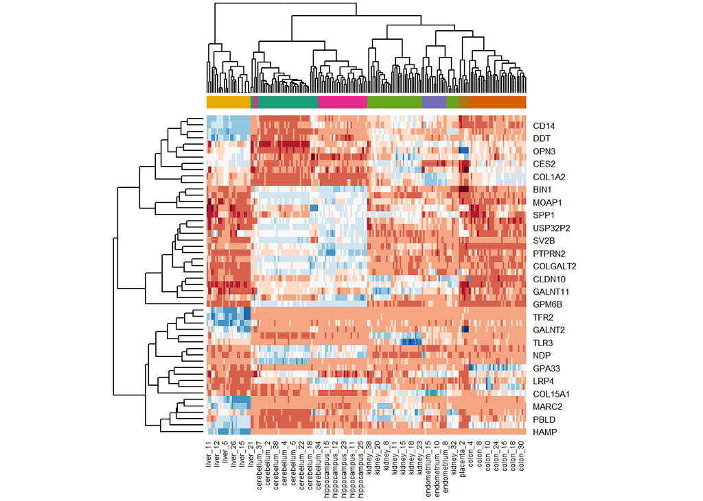

```r
library(RColorBrewer)
sds <- matrixStats::colSds(tissue_gene_expression$x)
ind <- order(sds, decreasing = TRUE)[1:50]
colors <- brewer.pal(7, "Dark2")[as.numeric(tissue_gene_expression$y)]
heatmap(t(tissue_gene_expression$x[,ind]), col = brewer.pal(11, "RdBu"), scale = "row", ColSideColors = colors)
```

Which line of code should replace #BLANK in the code above?

- `heatmap(t(tissue_gene_expression$x[,ind]), col = brewer.pal(11, "RdBu"), scale = "row", ColSideColors = colors)` [X]
- `heatmap(t(tissue_gene_expression$x[,ind]), col = brewer.pal(11, "RdBu"), scale = "row", ColSideColors = rev(colors))`
- `heatmap(t(tissue_gene_expression$x[,ind]), col = brewer.pal(11, "RdBu"), scale = "row", ColSideColors = sample(colors))`
- `heatmap(t(tissue_gene_expression$x[,ind]), col = brewer.pal(11, "RdBu"), scale = "row", ColSideColors = sample(colors))`